# State of Nevada: Minor Revenue Portfolio

High-Frequency Quarterly Risk Exposure & Structural 3-Year Projections

Author

Governor’s Finance Office — Budget Division

Published

September 14, 2026

## 1. Executive Summary

By evaluating structural data indicators against a baseline trend and an aggressive stagflationary demand shock, this framework isolates the state’s multi-period budgetary exposure. Over the 12-quarter outlook horizon (2027Q1 through 2029Q4), the total fiscal variance highlights critical stress points clustered within consumer retail allocations and tourism mobility assets.

## 2. Environment Setup & Data Loading

The pipeline establishes a localized directory workflow. It hooks directly into the raw ledger historical transactional extract file located at `../data/dawn_revenue_accounts_combined_history.csv`, filters for entries marked as `Minor`, and restricts data operations strictly to your 20 targeted account codes.

```python
import os
import pandas as pd
import numpy as np
import matplotlib.pyplot as plt
from IPython.display import display, HTML

# Establish structural directory coordinates
BASE_DIR = os.getcwd()
DATA_PATH = os.path.join(os.path.dirname(BASE_DIR), "data", "dawn_revenue_accounts_combined_history.csv")
RESULTS_DIR = os.path.join(os.path.dirname(BASE_DIR), "results")
os.makedirs(RESULTS_DIR, exist_ok=True)

# Define explicit 20 targeted GL codes filter mask array
target_gl_codes = [
    "3113", "3052", "3130", "3066", "3050", "3073", "3053", "3152", "3101", "3004",
    "3005", "3114", "3002", "3047", "3044", "3043", "3003", "3042", "3276", "3075"
]

# Structural sector descriptions dictionary registry
sector_labels = {
    "3113": "Business license fees", "3052": "Cigarette tax", "3130": "Corporate license fees",
    "3066": "Short term auto lease", "3050": "Liquor tax", "3073": "Transportation loan excise tax",
    "3053": "Other tobacco tax", "3152": "Securities fees", "3101": "Insurance license fees",
    "3004": "State share SCCRT", "3005": "Public transport tax (uber/lyft)",
    "3114": "Court administration assessment fees", "3002": "State share LSST",
    "3047": "Expired slot machine voucher", "3044": "Non-residential slot",
    "3043": "Flat fee restricted slot", "3003": "State share BCCRT",
    "3042": "Gaming penalties", "3276": "Cost recovery plan charge", "3075": "Lodging tax"
}

# Read raw dataset fields
ledger_df = pd.read_csv(DATA_PATH)
ledger_df.columns = ledger_df.columns.str.strip()

# Apply filter masks
minor_df = ledger_df[ledger_df['Type'].str.strip() == 'Minor'].copy()
minor_df['GL Number'] = minor_df['GL Number'].astype(str).str.strip()
filtered_df = minor_df[minor_df['GL Number'].isin(target_gl_codes)].copy()

# Cast dates and amounts safely to analytical series vectors
filtered_df['ParsedDate'] = pd.to_datetime(filtered_df['Date'], errors='coerce')
filtered_df['Quarter'] = filtered_df['ParsedDate'].dt.to_period('Q')
filtered_df['Amount'] = pd.to_numeric(filtered_df['Amount'], errors='coerce').fillna(0.0)

print(f"[SUCCESS] Loaded {len(filtered_df)} transaction log entries across target sectors.")
```

```
[SUCCESS] Loaded 106475 transaction log entries across target sectors.
```

## 3. Historical Data Aggregation

To establish clean timelines, the granular transaction lines are grouped into Year-Quarter segments. Below, we pivot the table and aggregate the net collection value for each active GL account number.

```python
# Group transactions by GL and Period
quarterly_pivot = filtered_df.groupby(['GL Number', 'Quarter'])['Amount'].sum().unstack(fill_value=0.0)
available_quarters = sorted(list(quarterly_pivot.columns))

start_q = available_quarters[0]
end_q = available_quarters[-1]
total_quarters_delta = (end_q.year - start_q.year) * 4 + (end_q.quarter - start_q.quarter)

print(f"Ingested timeline spans from {start_q} to {end_q} ({total_quarters_delta} operational intervals).")
```

```
Ingested timeline spans from 2000Q1 to 2026Q3 (106 operational intervals).
```

## 4. Forecasting Methodology by Sector

### Dynamic Trailing Quarterly CAGR Model

Every individual sector is indexed against its real historical performance by computing its **Compound Annual Growth Rate (CAGR)** on a quarterly scale:
$$\text{Quarterly CAGR} = \left( \frac{\text{Revenue}_{\text{End Quarter}}}{\text{Revenue}_{\text{Start Quarter}}} \right)^{\frac{1}{n}} - 1$$
*To ensure baseline stability, dynamic outlier swings are bounded within a standard $\pm4\%$ quarterly parameter.*

## 5. Multi-Period Simulation Engine

The loop below projects collections out for the next 12 consecutive future quarters (covering a 3-year forecasting horizon from 2027Q1 to 2029Q4).

```python
calculated_trends = {}
for gl_code, rows in quarterly_pivot.iterrows():
    start_val = rows[start_q]
    end_val = rows[end_q]

    if start_val > 0 and end_val > 0 and total_quarters_delta > 0:
        quarterly_cagr = (end_val / start_val) ** (1.0 / total_quarters_delta) - 1.0
        quarterly_cagr = max(min(quarterly_cagr, 0.04), -0.04)
    else:
        quarterly_cagr = 0.0035

    calculated_trends[gl_code] = {
        "baseline_stock": end_val,
        "quarterly_growth_rate": quarterly_cagr,
        "history_quarters": [str(q) for q in available_quarters],
        "history_values": [rows[q] for q in available_quarters]
    }

future_quarters = []
for yr in range(2027, 2030):
    for qtr in range(1, 5):
        future_quarters.append(f"{yr}Q{qtr}")

forecast_results = []
for gl_code, data in calculated_trends.items():
    name = sector_labels.get(gl_code, f"GL Account {gl_code}")
    base = data["baseline_stock"]
    q_growth = data["quarterly_growth_rate"]

    # Run Baseline Projections
    v_base = base
    p_base = []
    for qtr in future_quarters:
        v_base *= (1 + q_growth)
        p_base.append(v_base)

    # Run Stress-Test Projections
    v_stress = base
    p_stress = []
    stress_modifier = -0.015 if q_growth < 0 else -0.008
    for qtr in future_quarters:
        v_stress *= (1 + q_growth + stress_modifier)
        p_stress.append(v_stress)

    forecast_results.append({
        "gl_code": gl_code, "name": name, "cagr": q_growth,
        "history_qtrs": data["history_quarters"], "history_vals": data["history_values"],
        "future_qtrs": future_quarters, "base_pred": p_base, "stress_pred": p_stress
    })
print("[INFO] Multi-period quarterly simulation arrays loaded.")
```

```
[INFO] Multi-period quarterly simulation arrays loaded.
```

## 6. Historical Trends & Shaded Risk Ribbon Visualizations

This section applies corporate-style aesthetics to render the tracking charts for your portfolio. Each plot uses **Deep Nevada Navy** for historical data points, **Sagebrush Green** for the dynamic baseline, and a **Soft Coral Ribbon Corridor** to visually map out the state’s budget exposure gap over time.

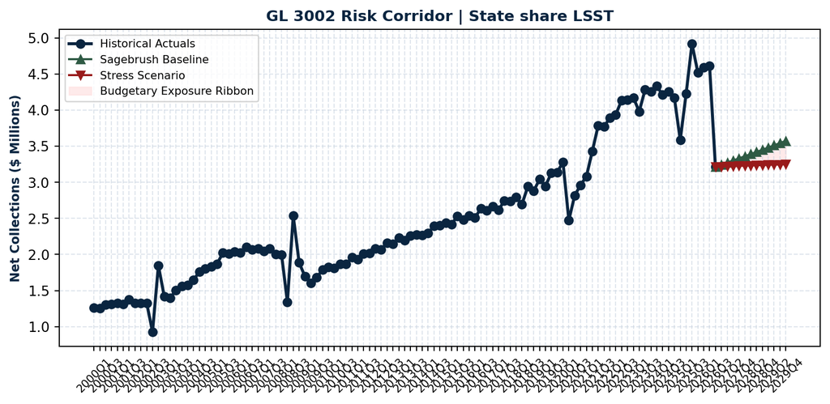

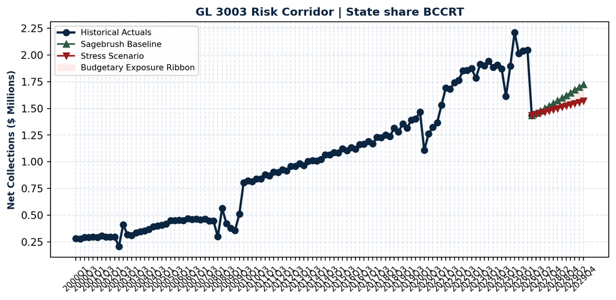

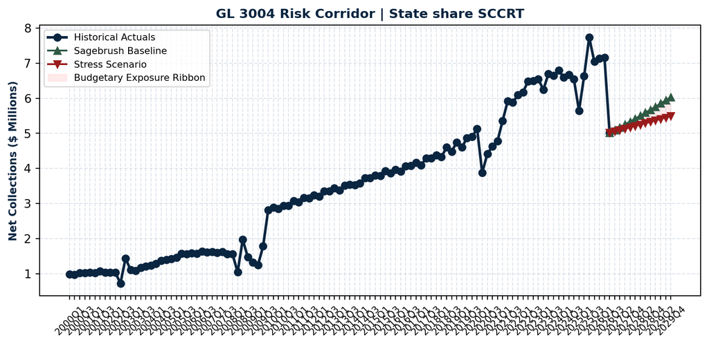

[figure not shown]

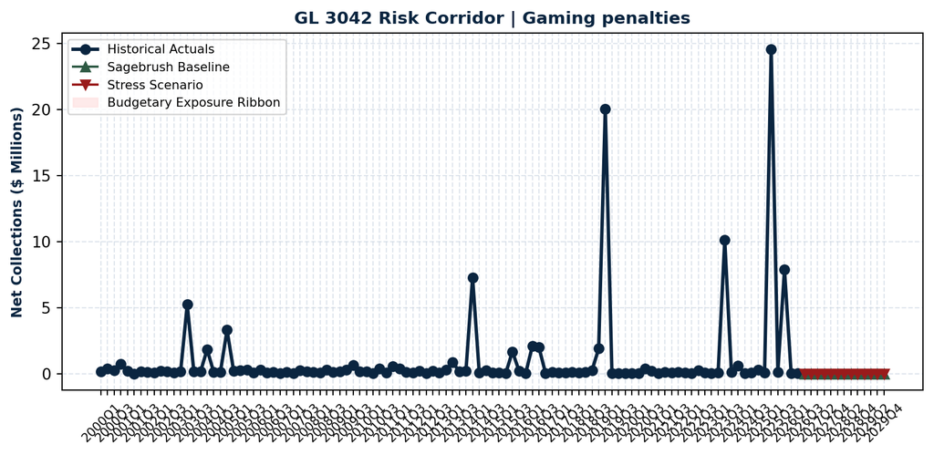

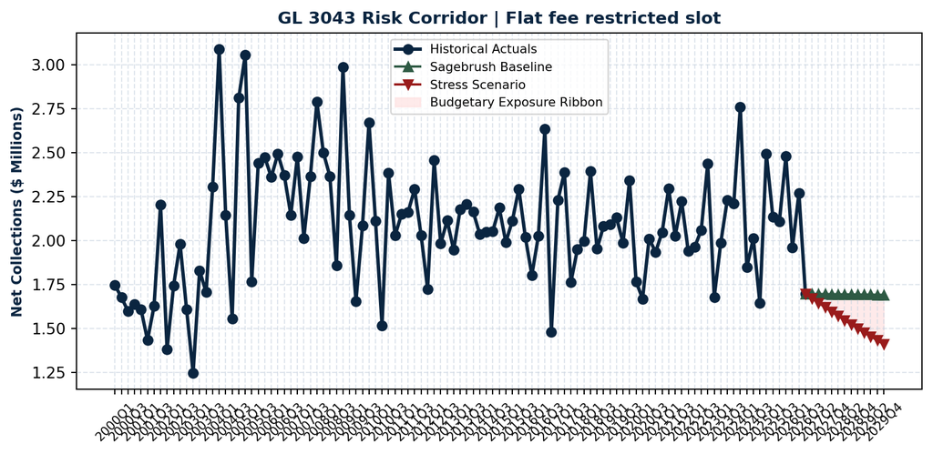

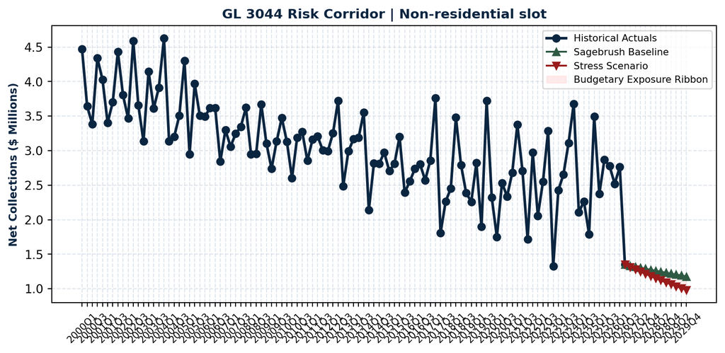

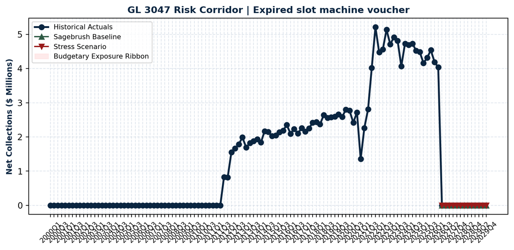

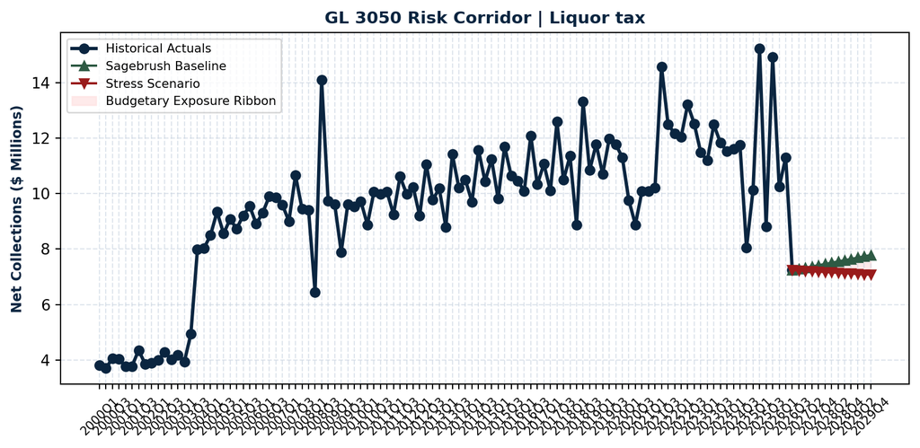

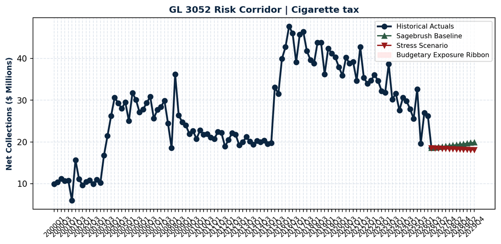

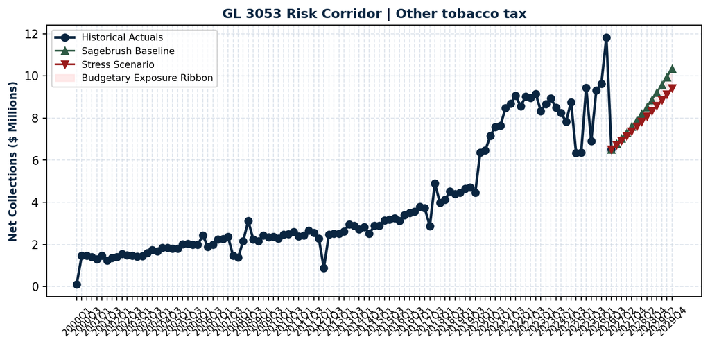

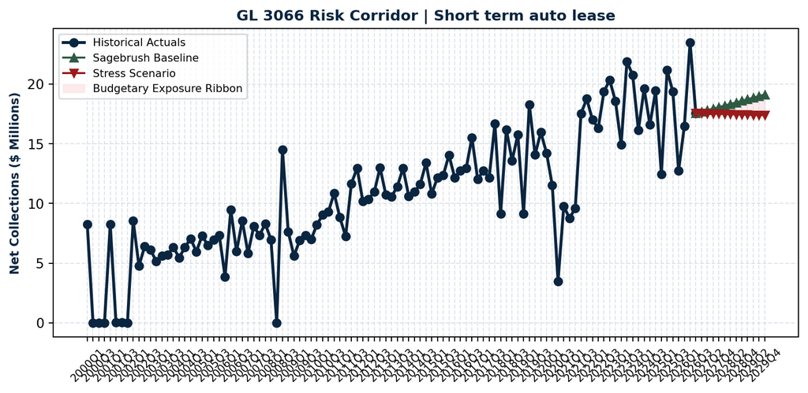

[8 more figures not shown]

```python
# Corporate Style Palette Configuration Constants
COLOR_HIST = "#0A2540"
COLOR_BASE = "#2E5A44"
COLOR_STRESS = "#991B1B"
COLOR_GRID = "#CBD5E1"
COLOR_RIBBON = "#FEE2E2"

# Direct inline plotting layout loop configuration
for f in forecast_results:
    fig, ax = plt.subplots(figsize=(8.5, 4.2))

    h_qtrs = f["history_qtrs"]
    h_vals = [v / 1e6 for v in f["history_vals"]]
    ax.plot(h_qtrs, h_vals, marker='o', color=COLOR_HIST, linewidth=2.2, label='Historical Actuals')

    f_qtrs = [h_qtrs[-1]] + f["future_qtrs"]
    f_base = [h_vals[-1]] + [v / 1e6 for v in f["base_pred"]]
    f_stress = [h_vals[-1]] + [v / 1e6 for v in f["stress_pred"]]

    ax.plot(f_qtrs, f_base, linestyle='-', marker='^', color=COLOR_BASE, linewidth=1.5, label='Sagebrush Baseline')
    ax.plot(f_qtrs, f_stress, linestyle='-', marker='v', color=COLOR_STRESS, linewidth=1.5, label='Stress Scenario')

    # Generate variance exposure shading ribbon
    ax.fill_between(f_qtrs, f_base, f_stress, color=COLOR_RIBBON, alpha=0.7, label='Budgetary Exposure Ribbon')

    ax.set_title(f"GL {f['gl_code']} Risk Corridor | {f['name']}", fontsize=11, fontweight='bold', color=COLOR_HIST)
    ax.set_ylabel("Net Collections ($ Millions)", fontsize=9, fontweight='bold', color=COLOR_HIST)
    ax.grid(True, linestyle='--', color=COLOR_GRID, alpha=0.6)

    # Formatting tick intervals nicely
    all_qtrs = h_qtrs + f["future_qtrs"]
    visible_labels = [q if idx % 2 == 0 else "" for idx, q in enumerate(all_qtrs)]
    ax.set_xticks(range(len(all_qtrs)))
    ax.set_xticklabels(visible_labels, rotation=45, fontsize=8)
    ax.legend(loc='best', fontsize=8)

    plt.tight_layout()
    plt.show()
```

## 7. Comparative Forecast Report Matrices

### Table 1: Quarterly Progress Milestone Projections (Baseline View)

This matrix tracks forecast performance under standard baseline operating assumptions, identifying first-quarter (`Q1`) benchmarks for each outlook year.

```python
t1_rows = []
for f in forecast_results:
    t1_rows.append({
        "GL Code": f["gl_code"],
        "Sector Name Description": f["name"],
        "FY 2027 Q1 Base": f"${f['base_pred'][0]/1e6:,.2f}M",
        "FY 2028 Q1 Base": f"${f['base_pred'][4]/1e6:,.2f}M",
        "FY 2029 Q1 Base": f"${f['base_pred'][8]/1e6:,.2f}M"
    })
t1_df = pd.DataFrame(t1_rows)
knitr_table1 = t1_df.to_html(index=False, classes="table table-striped table-hover")
display(HTML(knitr_table1))
```

| GL Code | Sector Name Description | FY 2027 Q1 Base | FY 2028 Q1 Base | FY 2029 Q1 Base |
| --- | --- | --- | --- | --- |
| 3002 | State share LSST | $3.25M | $3.36M | $3.48M |
| 3003 | State share BCCRT | $1.46M | $1.55M | $1.65M |
| 3004 | State share SCCRT | $5.10M | $5.42M | $5.76M |
| 3005 | Public transport tax (uber/lyft) | $3.98M | $4.34M | $4.74M |
| 3042 | Gaming penalties | $0.01M | $0.01M | $0.01M |
| 3043 | Flat fee restricted slot | $1.70M | $1.69M | $1.69M |
| 3044 | Non-residential slot | $1.34M | $1.28M | $1.22M |
| 3047 | Expired slot machine voucher | $0.00M | $0.00M | $0.00M |
| 3050 | Liquor tax | $7.28M | $7.46M | $7.64M |
| 3052 | Cigarette tax | $18.67M | $19.11M | $19.57M |
| 3053 | Other tobacco tax | $6.77M | $7.90M | $9.21M |
| 3066 | Short term auto lease | $17.70M | $18.21M | $18.73M |
| 3073 | Transportation loan excise tax | $9.79M | $9.92M | $10.06M |
| 3075 | Lodging tax | $1.69M | $1.72M | $1.74M |
| 3101 | Insurance license fees | $1.07M | $1.02M | $0.96M |
| 3113 | Business license fees | $5.58M | $6.41M | $7.38M |
| 3114 | Court administration assessment fees | $1.86M | $2.17M | $2.54M |
| 3130 | Corporate license fees | $3.79M | $3.72M | $3.66M |
| 3152 | Securities fees | $0.11M | $0.09M | $0.08M |
| 3276 | Cost recovery plan charge | $0.40M | $0.38M | $0.37M |

### Table 2: Step-by-Step Scenario Matrix (Base vs. Stress Contraction View)

This matrix features a high-resolution, period-by-period value contrast mapping out exactly how much each general ledger stream drifts when switching directly from baseline trends to stress models.

```python
t2_rows = []
for f in forecast_results:
    t2_rows.append({
        "GL Code": f["gl_code"],
        "Sector Description": f["name"],
        "2027Q1 Base": f"${f['base_pred'][0]/1e6:,.2f}M",
        "2027Q1 Stress": f"${f['stress_pred'][0]/1e6:,.2f}M",
        "2028Q1 Base": f"${f['base_pred'][4]/1e6:,.2f}M",
        "2028Q1 Stress": f"${f['stress_pred'][4]/1e6:,.2f}M",
        "2029Q1 Base": f"${f['base_pred'][8]/1e6:,.2f}M",
        "2029Q1 Stress": f"${f['stress_pred'][8]/1e6:,.2f}M"
    })
t2_df = pd.DataFrame(t2_rows)
knitr_table2 = t2_df.to_html(index=False, classes="table table-striped table-hover")
display(HTML(knitr_table2))
```

| GL Code | Sector Description | 2027Q1 Base | 2027Q1 Stress | 2028Q1 Base | 2028Q1 Stress | 2029Q1 Base | 2029Q1 Stress |
| --- | --- | --- | --- | --- | --- | --- | --- |
| 3002 | State share LSST | $3.25M | $3.22M | $3.36M | $3.23M | $3.48M | $3.24M |
| 3003 | State share BCCRT | $1.46M | $1.44M | $1.55M | $1.49M | $1.65M | $1.53M |
| 3004 | State share SCCRT | $5.10M | $5.06M | $5.42M | $5.21M | $5.76M | $5.37M |
| 3005 | Public transport tax (uber/lyft) | $3.98M | $3.95M | $4.34M | $4.17M | $4.74M | $4.41M |
| 3042 | Gaming penalties | $0.01M | $0.01M | $0.01M | $0.01M | $0.01M | $0.01M |
| 3043 | Flat fee restricted slot | $1.70M | $1.67M | $1.69M | $1.57M | $1.69M | $1.48M |
| 3044 | Non-residential slot | $1.34M | $1.32M | $1.28M | $1.18M | $1.22M | $1.06M |
| 3047 | Expired slot machine voucher | $0.00M | $0.00M | $0.00M | $0.00M | $0.00M | $0.00M |
| 3050 | Liquor tax | $7.28M | $7.23M | $7.46M | $7.17M | $7.64M | $7.11M |
| 3052 | Cigarette tax | $18.67M | $18.52M | $19.11M | $18.37M | $19.57M | $18.21M |
| 3053 | Other tobacco tax | $6.77M | $6.72M | $7.90M | $7.60M | $9.21M | $8.59M |
| 3066 | Short term auto lease | $17.70M | $17.55M | $18.21M | $17.50M | $18.73M | $17.44M |
| 3073 | Transportation loan excise tax | $9.79M | $9.71M | $9.92M | $9.53M | $10.06M | $9.36M |
| 3075 | Lodging tax | $1.69M | $1.68M | $1.72M | $1.65M | $1.74M | $1.62M |
| 3101 | Insurance license fees | $1.07M | $1.06M | $1.02M | $0.94M | $0.96M | $0.84M |
| 3113 | Business license fees | $5.58M | $5.53M | $6.41M | $6.17M | $7.38M | $6.88M |
| 3114 | Court administration assessment fees | $1.86M | $1.84M | $2.17M | $2.09M | $2.54M | $2.37M |
| 3130 | Corporate license fees | $3.79M | $3.73M | $3.72M | $3.45M | $3.66M | $3.19M |
| 3152 | Securities fees | $0.11M | $0.11M | $0.09M | $0.09M | $0.08M | $0.07M |
| 3276 | Cost recovery plan charge | $0.40M | $0.39M | $0.38M | $0.36M | $0.37M | $0.32M |

## 8. Stress-Test Performance Analysis

The simulation reveals that the stress-test adjustments significantly impact sectors tied directly to broader economic shifts. Because the stress model applies a continuous downward multiplier over the next 12 quarters, the revenue gap widens significantly over time.